# Testing Stability

Christiana McDonald-Spicer

20 October 2016

# Testing stability

This calculates the stability for a site and also maps general patterns of dissimilarity to the present. See also the R scripts “Testing\_Stability\_for\_a\_Site" and “Mapping_Stability”.

Stability plotted for individual cells is both static stability (a cell compared to itself through time) and buffer stability (looking at a radius around a single cell through time).

## Read in the data

First of all load the packages required.

```r
library(raster)
```

Set the folder containing the rasters transformed from the GDM. Each raster must contain the name of the time period, as given in “time_periods” below. The folder must also contain data from the present day, with “present” in the name

```r
data_folder <- "C:/Users/Christiana/Documents/Identifying stability/Data/transformed rasters/"
```

Set up a vector of all the time periods included in the analysis (not including the present day).

```r
time_periods <- c("002", "004", "006", "008", "010", "012", "014", "016", "018", "020", "022", "024", "026", "028", "030", "032", "034", "036", "038", "040", "042", "044", "046", "048", "050", "052", "054", "056", "058", "060", "062", "064", "066", "068", "070", "072", "074", "076", "078", "080", "084", "088", "092", "096", "100", "108", "112", "116", "120")
```

Find and create a raster stack of the files for the present day. The layers are sorted alphabetically to ensure they will be in the same order for all the time periods.

```r
rasters <- list.files(path = data_folder, pattern = "present")
rasters <- sort(rasters)
rasters <- paste(data_folder, rasters, sep="")
rasters.present <- stack(rasters)
```

\newpage

## Compare time periods to present

Here we compare each time period to the present day. We also summarise all the variables into one layer for each time period.

First of all, we create a function to compare the time periods to today. This first calculates the difference between the two time periods for each variable (layer in the stacks). It then takes the absolute value of this, before adding all the layers in the new stack together to create a summary of the dissimilarity for that time period.

```r
stab.func <- function(stack1, stack2) {
  #create new raster stack
  new.stack <- stack1
  new.stack[] <- NA

  #perform calculation for each stack
  new.stack <- abs(stack1-stack2)

  #add all layers together
  added_raster <- sum(new.stack)
}
```

```r
run.stab.func <- function(present, time, folder){
  #read in and stack the files for the relevant time period
  rasters <- list.files(path = folder, pattern = time)
  rasters <- sort(rasters)
  rasters <- paste(data_folder, rasters, sep="")
  stack_rasters <- stack(rasters)

  #apply stability fuction
  result <- stab.func(present, stack_rasters)

  #apply GDM link function
  result <- 1 - exp(-1 * result)
}
```

Now that we have these two functions, we can run them to calculate the dissimilarity of the species assemblages in each time period to the present.

```r
for (i in time_periods) {
  #run the analysis
  result <- run.stab.func(rasters.present, i, data_folder)

  #give the output a relevant name
  assign(paste0("stability.", i), result)
  }
```

Finally, we will stack the output rasters.

```r
stab.rasters <- stack(mget(ls(pattern = "stability")))
```

\newpage

## Looking at stability in a single cell

Now we have the stability for each time period summarised, we can look at the stability in a single cell over time. In this example we will use Katherine (NT).

First set the coordinates and format them as SpatialPoints.

```r
coords <- data.frame(132.27, -14.45)
points <- coords
colnames(points) <- c("lon", "lat")
coordinates(points) <- c("lon", "lat")
```

We also need to set a buffer for looking at a radius around a cell. This is measured in the units of your raster files, usually metres.

```r
buffer <- 50000
```

Now we have everything set up, we will extract the data for static stability (comparing a single cell to itself through time), and add in details for the present day.

```r
stability.df <- data.frame(extract(stab.rasters, points))
colnames(stability.df) <- time_periods
stability.df <- cbind("000" = 0, stability.df)
```

We also want to add the present day into our list of time periods.

```r
n <- c(0)
time_periods_0 <- c(n, time_periods)
```

```r
buffer.df <- extract(stab.rasters, points, buffer = buffer, fun=max)
colnames(buffer.df) <- time_periods
buffer.df <- cbind("000" = 0, buffer.df)
```

Combine the two dataframes together with the time periods.

```r
stability.df2 <- rbind(stability.df, time_periods_0, buffer.df)
stability.df2 <- t(stability.df2)
colnames(stability.df2) <- c("static", "time", "buffer")
stability.df2 <- stability.df2[,c("time", "static", "buffer")]
```

A bit of housekeeping to make sure the dataframe is in the correct format.

```r
stability.df2 <- as.data.frame(stability.df2)
stability.df2$static <- as.numeric(as.character(stability.df2$static))
stability.df2$time <- as.numeric(as.character(stability.df2$time))
stability.df2$buffer <- as.numeric(as.character(stability.df2$buffer))
head(stability.df2)
```

```
##     time     static     buffer
## 000    0 0.00000000 0.00000000
## 002    2 0.02067009 0.04083941
## 004    4 0.02243577 0.02667364
## 006    6 0.01476491 0.04232678
## 008    8 0.01303461 0.04159603
## 010   10 0.02954216 0.05707693
```

Finally we can plot the data.

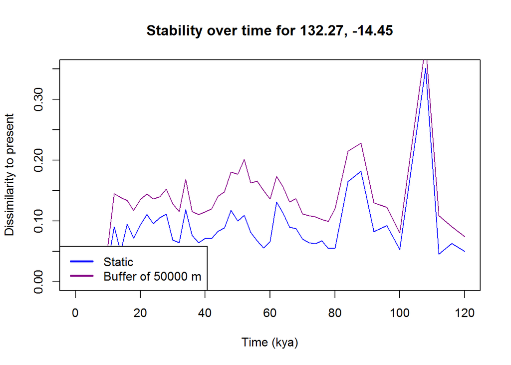

Figure 1: Stability over time present-120kya

We can also plot from just 80kya, as the data between 80 and 120kya doesn’t look credible.

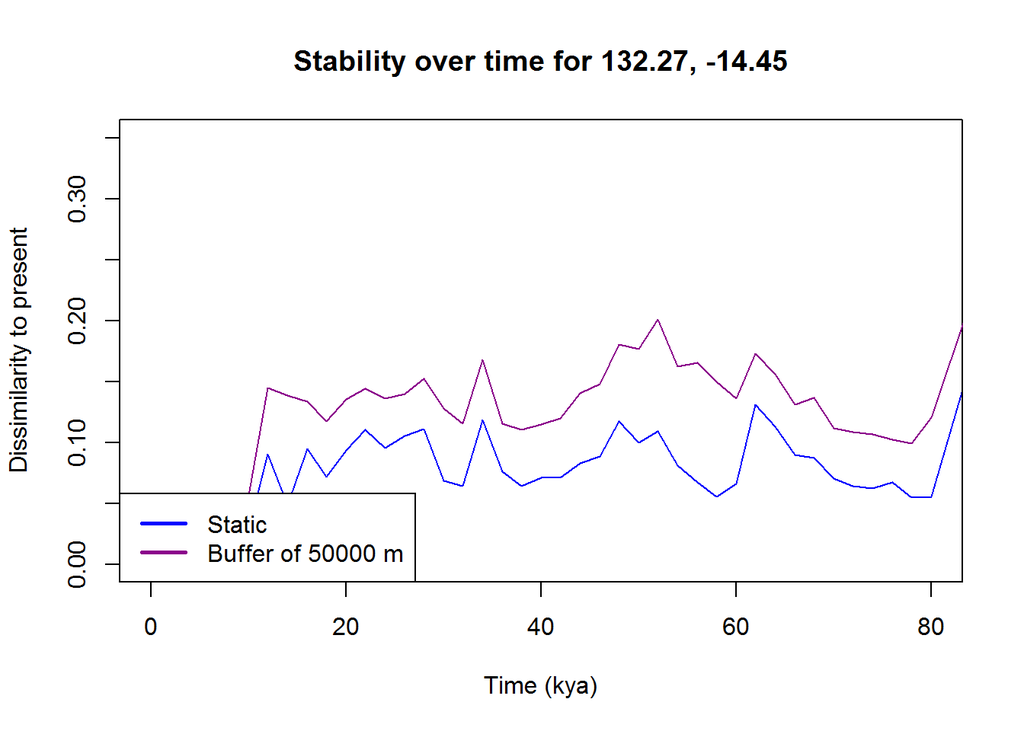

Figure 2: Stability over time present-80kya

\newpage

## Plotting maps of stability

There are four metrics I am looking at currently - arithemetic mean, standard deviation, range and geometric mean.

First I crop the rasters to my study region (the one used to fit the GDM originally). This makes it faster to calculate and easier to view the patterns in the plots.

```r
study_extent <- c(111, 156, -25.5, -9.008331)
stab.rasters.crop <- crop(stab.rasters, study_extent)
```

Then I can calculate the arithmetic mean:

```r
stab_arithmean <- calc(stab.rasters.crop, fun=mean)
```

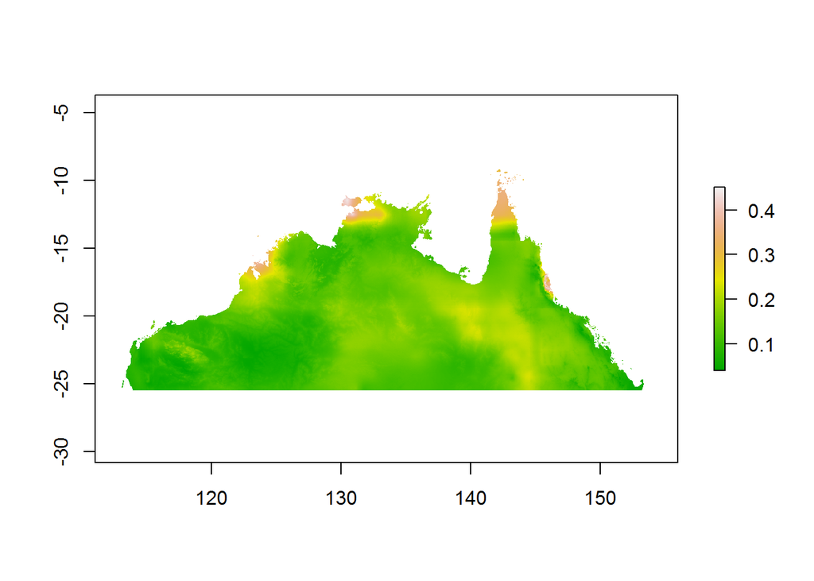

Figure 3: Arithmetic mean of dissimilarity. More negative means more dissimilar

The standard deviation:

```r
stab_sdev <- calc(stab.rasters.crop, fun=sd)
```

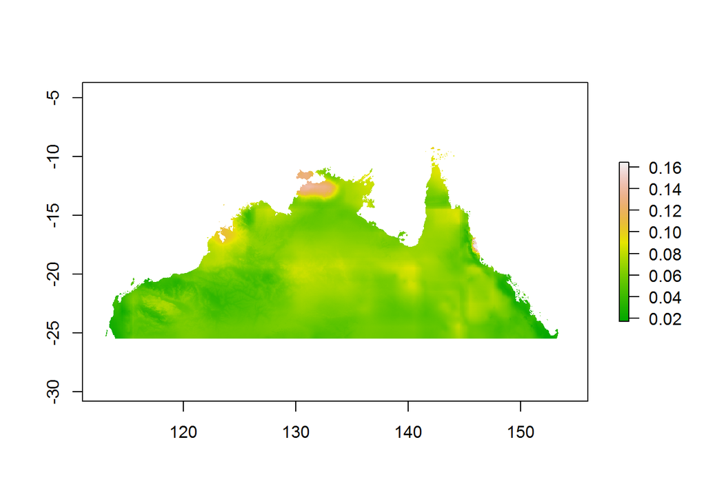

Figure 4: Standard deviation of dissimilarity. More negative means more dissimilar

The range:

```r
stab_range <- calc(stab.rasters.crop, fun=function(x){max(x)-min(x)})
```

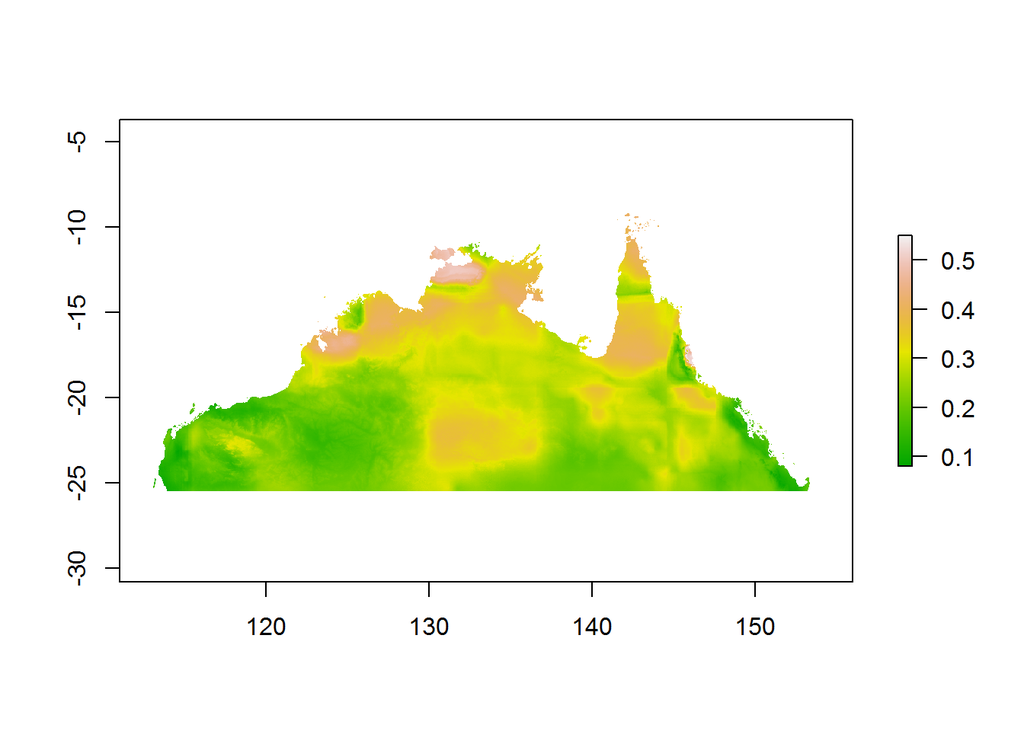

Figure 5: Range of dissimilarity. More negative means more dissimilar

And the geometric mean. As the geometric mean cannot be calculated with negative numbers, this function first takes the absolute value.

```r
stab_geomean <- calc(stab.rasters.crop, fun=function(x){exp(mean(log(abs(x))))})
```

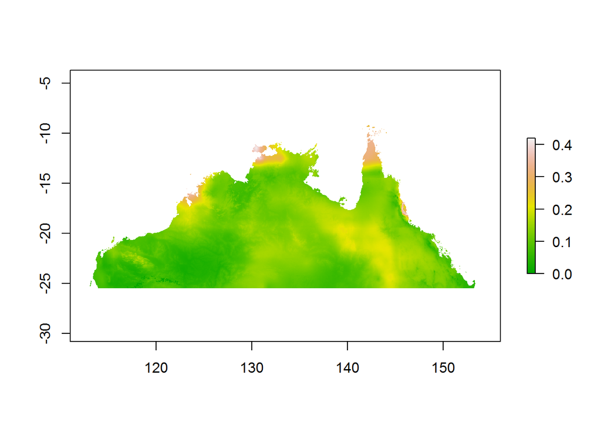

Figure 6: Geometric mean of dissimilarity. More negative means more dissimilar

The patterns seen here may be impacted by endemic species with small ranges in the areas of high dissimilarity?

\newpage

## Plotting Bioclim variables through time

We can do similar plots for the bioclim variables used in the GDM.

As we have already set up our study extent and coordinates, we just need to read in the rasters for each time period. This is working with the raw data, not the transformed layers.

```r
folder <- "C:/Users/Christiana/Documents/gdm/past layers/"
bioclim.layer <- "bioclim_12"
bioclim <- list()

for (i in time_periods){
  bioclim[i] <- list.files(path = paste0(folder, i, "/"), pattern = bioclim.layer,
                            all.files=TRUE, full.names=TRUE)
}
bioclim <- unlist(bioclim)
bioclim <- sort(bioclim)
stack_bioclim <- stack(bioclim)
stack_bioclim <- crop(stack_bioclim, study_extent)
```

We also need to read in the current data.

```r
present_bioclim <- raster("C:/Users/Christiana/Documents/gdm/present_layers/bioclim_12.asc")
present_bioclim <- crop(present_bioclim, study_extent)
present_max <- maxValue(present_bioclim)
present_max
```

```
## [1] 4511
```

```r
present_min <- minValue(present_bioclim)
present_min
```

```
## [1] 131
```

We then extract the data for our point as we did earlier.

```r
bioclim.df <- data.frame(extract(stack_bioclim, points))
colnames(bioclim.df) <- time_periods

buffer.bioclim.df <- extract(stack_bioclim, points, buffer = buffer, fun=max)
buffer.bioclim.df <- t(buffer.bioclim.df)

bioclim.df2 <- rbind(bioclim.df, time_periods)
bioclim.df2 <- t(bioclim.df2)
bioclim.df2 <- cbind(bioclim.df2, buffer.bioclim.df)

colnames(bioclim.df2) <- c("static", "time", "buffer")
bioclim.df2 <- bioclim.df2[,c("time", "static", "buffer")]

bioclim.df2 <- as.data.frame(bioclim.df2)
bioclim.df2$static <- as.numeric(as.character(bioclim.df2$static))
bioclim.df2$time <- as.numeric(as.character(bioclim.df2$time))
bioclim.df2$buffer <- as.numeric(as.character(bioclim.df2$buffer))
head(bioclim.df2)
```

```
##     time static buffer
## 002    2   1095   1354
## 004    4   1012   1268
## 006    6   1007   1307
## 008    8   1039   1327
## 010   10   1111   1443
## 012   12   1135   1489
```

Then we plot it. The straight lines show the maximum and minimum values in the training data.

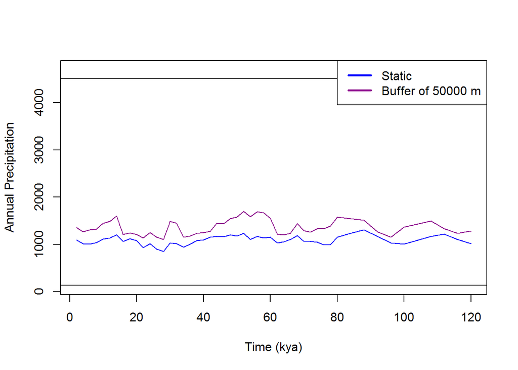

Figure 7: Plot of Annual Precipitation for Katherine

Do the same thing to plot the other Bioclim variables used:

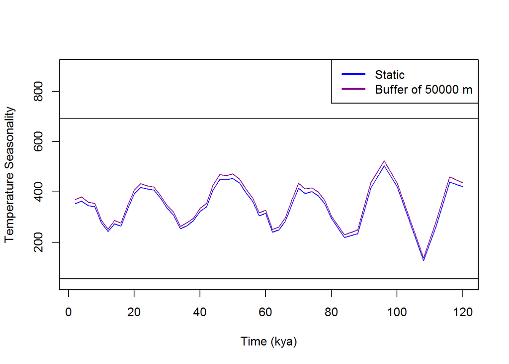

Figure 8: Plot of Temperature Seasonality for Katherine

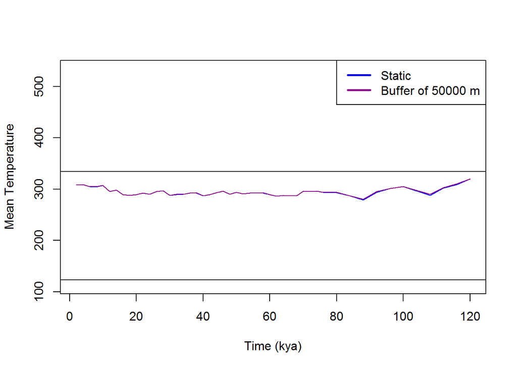

Figure 9: Plot of the Mean Temperature of the Warmest Quarter for Katherine

\newpage

## Mapping Bioclim variables through time

We can produce similar maps to those we made before for each of the bioclim variables.

We start by reading in the present data.

```r
present_bioclim <- raster("C:/Users/Christiana/Documents/gdm/present_layers/bioclim_10.asc")
present_bioclim <- crop(present_bioclim, study_extent)
```

We then create a stack of the past layers

```r
bioclim.layer <- "bioclim_10"
folder <- "C:/Users/Christiana/Documents/gdm/past layers/"
bioclim <- list()

for (i in time_periods){
  bioclim[i] <- list.files(path = paste0(folder, i, "/"), pattern = bioclim.layer,
                            all.files=TRUE, full.names=TRUE)
}
bioclim <- unlist(bioclim)
bioclim <- sort(bioclim)
stack_bioclim <- stack(bioclim)
stack_bioclim <- crop(stack_bioclim, study_extent)
```

We can apply the stability function.

```r
result <- stab.func(present_bioclim, stack_bioclim)
```

Then I can calculate the arithmetic mean:

```r
stab_arithmean <- calc(result, fun=mean)
```

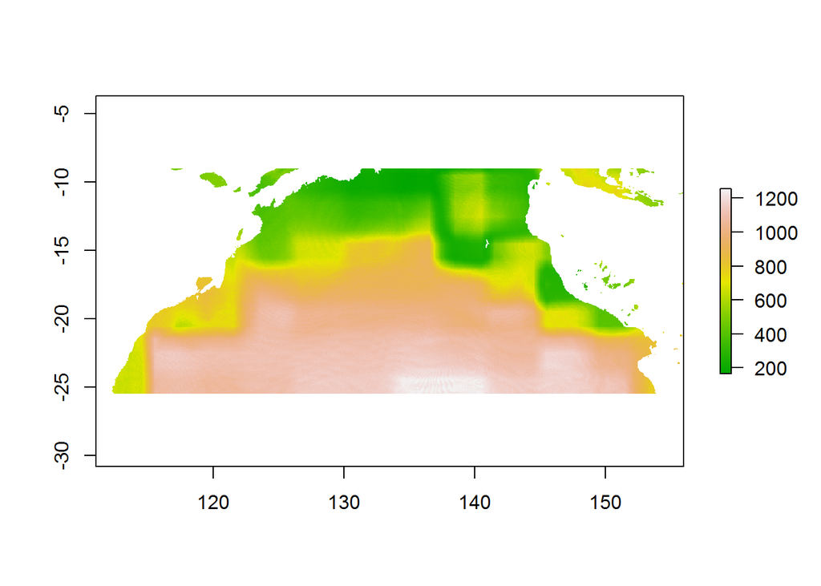

Figure 10: Arithmetic mean of dissimilarity for Bioclim10. More positive means more dissimilar

We can also do this for the other two Bioclim variables.

Firstly for Temperature seasonality:

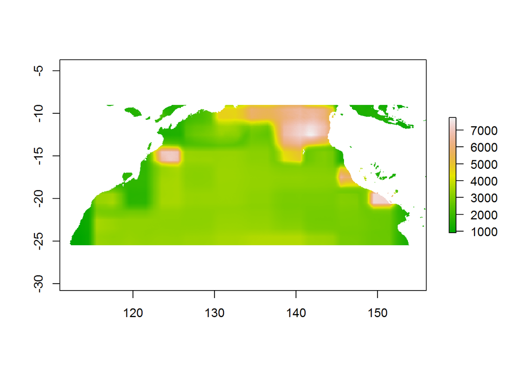

Figure 11: Arithmetic mean of dissimilarity for Bioclim04. More positive means more dissimilar

And then for Annual Precipitation:

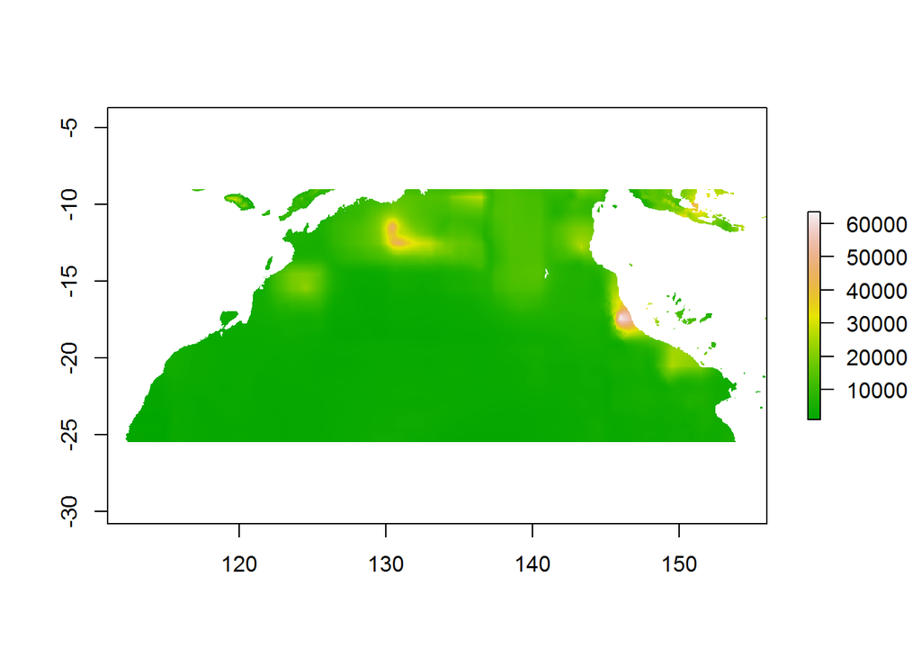

Figure 12: Arithmetic mean of dissimilarity for Bioclim12. More positive means more dissimilar